# Risk Factor Analysis

## Outcome Variable

**Outcome Variable:** whz

## Predictor Variables

**Intervention Variable:** predfeed6

**Adjustment Set:**

- arm
- sex
- month
- brthmon
- W_mage
- meducyrs
- feducyrs
- hhwealth_quart
- hfoodsec
- W_mhtcm
- W_mwtkg
- W_mbmi
- vagbrth
- W_gagebrth
- W_birthwt
- W_birthlen
- W_nrooms
- W_nchldlt5
- W_parity
- impfloor
- impsan
- safeh20
- delta_W_mage
- delta_meducyrs
- delta_feducyrs
- delta_hhwealth_quart
- delta_hfoodsec
- delta_W_mhtcm
- delta_W_mwtkg
- delta_W_mbmi
- delta_vagbrth
- delta_W_gagebrth
- delta_W_birthwt
- delta_W_birthlen
- delta_W_nrooms
- delta_W_nchldlt5
- delta_W_parity
- delta_impfloor
- delta_impsan
- delta_safeh20

## Stratifying Variables

The analysis was stratified on these variable(s):

- agecat
- studyid
- country

## Data Summary

| agecat | studyid | country | predfeed6 | n_cell | n | outcome_variable |
| --- | --- | --- | --- | --- | --- | --- |
| Birth | EE | PAKISTAN | 1 | 24 | 28 | whz |
| Birth | EE | PAKISTAN | 0 | 4 | 28 | whz |
| Birth | GMS-Nepal | NEPAL | 1 | 390 | 522 | whz |
| Birth | GMS-Nepal | NEPAL | 0 | 132 | 522 | whz |
| Birth | JiVitA-3 | BANGLADESH | 1 | 8392 | 10744 | whz |
| Birth | JiVitA-3 | BANGLADESH | 0 | 2352 | 10744 | whz |
| Birth | JiVitA-4 | BANGLADESH | 1 | 1802 | 2224 | whz |
| Birth | JiVitA-4 | BANGLADESH | 0 | 422 | 2224 | whz |
| Birth | MAL-ED | BANGLADESH | 1 | 68 | 194 | whz |
| Birth | MAL-ED | BANGLADESH | 0 | 126 | 194 | whz |
| Birth | MAL-ED | BRAZIL | 1 | 5 | 57 | whz |
| Birth | MAL-ED | BRAZIL | 0 | 52 | 57 | whz |
| Birth | MAL-ED | INDIA | 1 | 4 | 37 | whz |
| Birth | MAL-ED | INDIA | 0 | 33 | 37 | whz |
| Birth | MAL-ED | NEPAL | 1 | 3 | 23 | whz |
| Birth | MAL-ED | NEPAL | 0 | 20 | 23 | whz |
| Birth | MAL-ED | PERU | 1 | 72 | 208 | whz |
| Birth | MAL-ED | PERU | 0 | 136 | 208 | whz |
| Birth | MAL-ED | SOUTH AFRICA | 1 | 1 | 90 | whz |
| Birth | MAL-ED | SOUTH AFRICA | 0 | 89 | 90 | whz |
| Birth | MAL-ED | TANZANIA, UNITED REPUBLIC OF | 1 | 0 | 105 | whz |
| Birth | MAL-ED | TANZANIA, UNITED REPUBLIC OF | 0 | 105 | 105 | whz |
| 6 months | EE | PAKISTAN | 1 | 43 | 48 | whz |
| 6 months | EE | PAKISTAN | 0 | 5 | 48 | whz |
| 6 months | GMS-Nepal | NEPAL | 1 | 406 | 547 | whz |
| 6 months | GMS-Nepal | NEPAL | 0 | 141 | 547 | whz |
| 6 months | JiVitA-3 | BANGLADESH | 1 | 7625 | 9882 | whz |
| 6 months | JiVitA-3 | BANGLADESH | 0 | 2257 | 9882 | whz |
| 6 months | JiVitA-4 | BANGLADESH | 1 | 3327 | 4275 | whz |
| 6 months | JiVitA-4 | BANGLADESH | 0 | 948 | 4275 | whz |
| 6 months | LCNI-5 | MALAWI | 1 | 47 | 272 | whz |
| 6 months | LCNI-5 | MALAWI | 0 | 225 | 272 | whz |
| 6 months | MAL-ED | BANGLADESH | 1 | 84 | 231 | whz |
| 6 months | MAL-ED | BANGLADESH | 0 | 147 | 231 | whz |
| 6 months | MAL-ED | BRAZIL | 1 | 30 | 209 | whz |
| 6 months | MAL-ED | BRAZIL | 0 | 179 | 209 | whz |
| 6 months | MAL-ED | INDIA | 1 | 11 | 218 | whz |
| 6 months | MAL-ED | INDIA | 0 | 207 | 218 | whz |
| 6 months | MAL-ED | NEPAL | 1 | 12 | 225 | whz |
| 6 months | MAL-ED | NEPAL | 0 | 213 | 225 | whz |
| 6 months | MAL-ED | PERU | 1 | 92 | 271 | whz |
| 6 months | MAL-ED | PERU | 0 | 179 | 271 | whz |
| 6 months | MAL-ED | SOUTH AFRICA | 1 | 3 | 233 | whz |
| 6 months | MAL-ED | SOUTH AFRICA | 0 | 230 | 233 | whz |
| 6 months | MAL-ED | TANZANIA, UNITED REPUBLIC OF | 1 | 1 | 232 | whz |
| 6 months | MAL-ED | TANZANIA, UNITED REPUBLIC OF | 0 | 231 | 232 | whz |
| 6 months | SAS-FoodSuppl | INDIA | 1 | 0 | 168 | whz |
| 6 months | SAS-FoodSuppl | INDIA | 0 | 168 | 168 | whz |
| 24 months | EE | PAKISTAN | 1 | 20 | 23 | whz |
| 24 months | EE | PAKISTAN | 0 | 3 | 23 | whz |
| 24 months | GMS-Nepal | NEPAL | 1 | 355 | 469 | whz |
| 24 months | GMS-Nepal | NEPAL | 0 | 114 | 469 | whz |
| 24 months | JiVitA-3 | BANGLADESH | 1 | 3909 | 5067 | whz |
| 24 months | JiVitA-3 | BANGLADESH | 0 | 1158 | 5067 | whz |
| 24 months | JiVitA-4 | BANGLADESH | 1 | 3278 | 4184 | whz |
| 24 months | JiVitA-4 | BANGLADESH | 0 | 906 | 4184 | whz |
| 24 months | LCNI-5 | MALAWI | 1 | 34 | 184 | whz |
| 24 months | LCNI-5 | MALAWI | 0 | 150 | 184 | whz |
| 24 months | MAL-ED | BANGLADESH | 1 | 76 | 205 | whz |
| 24 months | MAL-ED | BANGLADESH | 0 | 129 | 205 | whz |
| 24 months | MAL-ED | BRAZIL | 1 | 25 | 169 | whz |
| 24 months | MAL-ED | BRAZIL | 0 | 144 | 169 | whz |
| 24 months | MAL-ED | INDIA | 1 | 11 | 209 | whz |
| 24 months | MAL-ED | INDIA | 0 | 198 | 209 | whz |
| 24 months | MAL-ED | NEPAL | 1 | 12 | 219 | whz |
| 24 months | MAL-ED | NEPAL | 0 | 207 | 219 | whz |
| 24 months | MAL-ED | PERU | 1 | 68 | 201 | whz |
| 24 months | MAL-ED | PERU | 0 | 133 | 201 | whz |
| 24 months | MAL-ED | SOUTH AFRICA | 1 | 3 | 216 | whz |
| 24 months | MAL-ED | SOUTH AFRICA | 0 | 213 | 216 | whz |
| 24 months | MAL-ED | TANZANIA, UNITED REPUBLIC OF | 1 | 1 | 202 | whz |
| 24 months | MAL-ED | TANZANIA, UNITED REPUBLIC OF | 0 | 201 | 202 | whz |

The following strata were considered:

- agecat: 24 months, studyid: EE, country: PAKISTAN
- agecat: 24 months, studyid: GMS-Nepal, country: NEPAL
- agecat: 24 months, studyid: JiVitA-3, country: BANGLADESH
- agecat: 24 months, studyid: JiVitA-4, country: BANGLADESH
- agecat: 24 months, studyid: LCNI-5, country: MALAWI
- agecat: 24 months, studyid: MAL-ED, country: BANGLADESH
- agecat: 24 months, studyid: MAL-ED, country: BRAZIL
- agecat: 24 months, studyid: MAL-ED, country: INDIA
- agecat: 24 months, studyid: MAL-ED, country: NEPAL
- agecat: 24 months, studyid: MAL-ED, country: PERU
- agecat: 24 months, studyid: MAL-ED, country: SOUTH AFRICA
- agecat: 24 months, studyid: MAL-ED, country: TANZANIA, UNITED REPUBLIC OF
- agecat: 6 months, studyid: EE, country: PAKISTAN
- agecat: 6 months, studyid: GMS-Nepal, country: NEPAL
- agecat: 6 months, studyid: JiVitA-3, country: BANGLADESH
- agecat: 6 months, studyid: JiVitA-4, country: BANGLADESH
- agecat: 6 months, studyid: LCNI-5, country: MALAWI
- agecat: 6 months, studyid: MAL-ED, country: BANGLADESH
- agecat: 6 months, studyid: MAL-ED, country: BRAZIL
- agecat: 6 months, studyid: MAL-ED, country: INDIA
- agecat: 6 months, studyid: MAL-ED, country: NEPAL
- agecat: 6 months, studyid: MAL-ED, country: PERU
- agecat: 6 months, studyid: MAL-ED, country: SOUTH AFRICA
- agecat: 6 months, studyid: MAL-ED, country: TANZANIA, UNITED REPUBLIC OF
- agecat: 6 months, studyid: SAS-FoodSuppl, country: INDIA
- agecat: Birth, studyid: EE, country: PAKISTAN
- agecat: Birth, studyid: GMS-Nepal, country: NEPAL
- agecat: Birth, studyid: JiVitA-3, country: BANGLADESH
- agecat: Birth, studyid: JiVitA-4, country: BANGLADESH
- agecat: Birth, studyid: MAL-ED, country: BANGLADESH
- agecat: Birth, studyid: MAL-ED, country: BRAZIL
- agecat: Birth, studyid: MAL-ED, country: INDIA
- agecat: Birth, studyid: MAL-ED, country: NEPAL
- agecat: Birth, studyid: MAL-ED, country: PERU
- agecat: Birth, studyid: MAL-ED, country: SOUTH AFRICA
- agecat: Birth, studyid: MAL-ED, country: TANZANIA, UNITED REPUBLIC OF

### Dropped Strata

Some strata were dropped due to rare outcomes:

- agecat: Birth, studyid: EE, country: PAKISTAN
- agecat: Birth, studyid: MAL-ED, country: INDIA
- agecat: Birth, studyid: MAL-ED, country: NEPAL
- agecat: Birth, studyid: MAL-ED, country: SOUTH AFRICA
- agecat: Birth, studyid: MAL-ED, country: TANZANIA, UNITED REPUBLIC OF
- agecat: 6 months, studyid: MAL-ED, country: SOUTH AFRICA
- agecat: 6 months, studyid: MAL-ED, country: TANZANIA, UNITED REPUBLIC OF
- agecat: 6 months, studyid: SAS-FoodSuppl, country: INDIA
- agecat: 24 months, studyid: EE, country: PAKISTAN
- agecat: 24 months, studyid: MAL-ED, country: SOUTH AFRICA
- agecat: 24 months, studyid: MAL-ED, country: TANZANIA, UNITED REPUBLIC OF

## Methods Detail

We’re interested in the causal parameters $E[Y_a]$ for all values of $a \in \mathcal{A}$. These parameters represent the mean outcome if, possibly contrary to fact, we intervened to set all units to have $A=a$. Under the randomization and positivity assumptions, these are identified by the statistical parameters $\psi_a=E_W[E_{Y|A,W}(Y|A=a,W)]$. In addition, we’re interested in the mean of $Y$, $E[Y]$ under no intervention (the observed mean). We will estimate these parameters by using SuperLearner to fit the relevant likelihood factors – $E_{Y|A,W}(Y|A=a,W)$ and $p(A=a|W)$, and then updating our likelihood fit using a joint TMLE.

For unadjusted analyses ($W=\{\}$), initial likelihoods were estimated using Lrnr_glm to estimate the simple $E(Y|A)$ and Lrnr_mean to estimate $p(A)$. For adjusted analyses, a small library containing Lrnr_glmnet, Lrnr_xgboost, and Lrnr_mean was used.

Having estimated these parameters, we will then use the delta method to estimate relative risks and attributable risks relative to a prespecified baseline level of $A$.

# Results Detail

## Results Plots

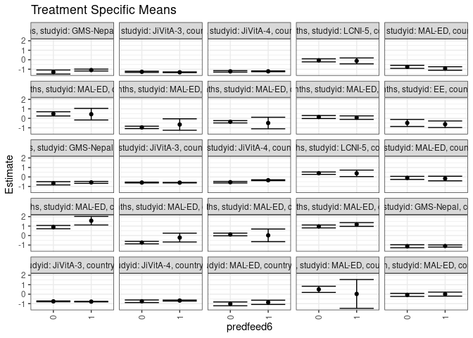

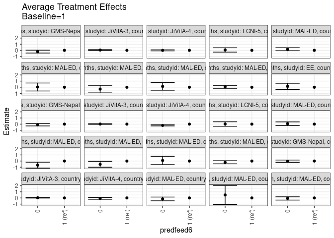

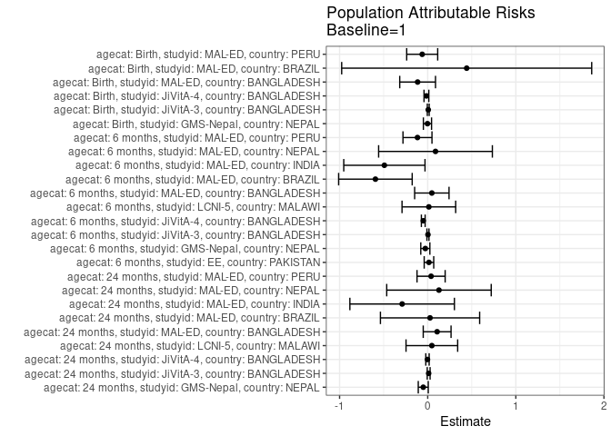

## Results Table

### Parameter: TSM

| agecat | studyid | country | intervention_level | baseline_level | estimate | ci_lower | ci_upper |
| --- | --- | --- | --- | --- | --- | --- | --- |
| Birth | GMS-Nepal | NEPAL | 1 | NA | -1.1036305 | -1.2163462 | -0.9909149 |
| Birth | GMS-Nepal | NEPAL | 0 | NA | -1.1269905 | -1.2869834 | -0.9669976 |
| Birth | JiVitA-3 | BANGLADESH | 1 | NA | -0.7869602 | -0.8117892 | -0.7621312 |
| Birth | JiVitA-3 | BANGLADESH | 0 | NA | -0.7595592 | -0.8034325 | -0.7156860 |
| Birth | JiVitA-4 | BANGLADESH | 1 | NA | -0.6758145 | -0.7305560 | -0.6210729 |
| Birth | JiVitA-4 | BANGLADESH | 0 | NA | -0.7499115 | -0.8866203 | -0.6132028 |
| Birth | MAL-ED | BANGLADESH | 1 | NA | -0.8610279 | -1.0842020 | -0.6378538 |
| Birth | MAL-ED | BANGLADESH | 0 | NA | -1.0238706 | -1.2254880 | -0.8222532 |
| Birth | MAL-ED | BRAZIL | 1 | NA | 0.0220000 | -1.4978207 | 1.5418207 |
| Birth | MAL-ED | BRAZIL | 0 | NA | 0.5069231 | 0.1803892 | 0.8334570 |
| Birth | MAL-ED | PERU | 1 | NA | 0.0038350 | -0.2074734 | 0.2151434 |
| Birth | MAL-ED | PERU | 0 | NA | -0.0775854 | -0.2404216 | 0.0852507 |
| 6 months | EE | PAKISTAN | 1 | NA | -0.6248062 | -0.9715960 | -0.2780164 |
| 6 months | EE | PAKISTAN | 0 | NA | -0.4893333 | -0.8590751 | -0.1195916 |
| 6 months | GMS-Nepal | NEPAL | 1 | NA | -0.5738563 | -0.6763651 | -0.4713476 |
| 6 months | GMS-Nepal | NEPAL | 0 | NA | -0.6704641 | -0.8412155 | -0.4997128 |
| 6 months | JiVitA-3 | BANGLADESH | 1 | NA | -0.6028982 | -0.6299685 | -0.5758278 |
| 6 months | JiVitA-3 | BANGLADESH | 0 | NA | -0.5909332 | -0.6366716 | -0.5451948 |
| 6 months | JiVitA-4 | BANGLADESH | 1 | NA | -0.3463171 | -0.3910063 | -0.3016280 |
| 6 months | JiVitA-4 | BANGLADESH | 0 | NA | -0.5546671 | -0.6344739 | -0.4748604 |
| 6 months | LCNI-5 | MALAWI | 1 | NA | 0.3795774 | 0.0389546 | 0.7202001 |
| 6 months | LCNI-5 | MALAWI | 0 | NA | 0.3983253 | 0.2718407 | 0.5248099 |
| 6 months | MAL-ED | BANGLADESH | 1 | NA | -0.1681433 | -0.4103387 | 0.0740521 |
| 6 months | MAL-ED | BANGLADESH | 0 | NA | -0.0993813 | -0.2621277 | 0.0633651 |
| 6 months | MAL-ED | BRAZIL | 1 | NA | 1.5655371 | 1.1148977 | 2.0161765 |
| 6 months | MAL-ED | BRAZIL | 0 | NA | 0.8929536 | 0.7188688 | 1.0670385 |
| 6 months | MAL-ED | INDIA | 1 | NA | -0.2149730 | -0.6779515 | 0.2480056 |
| 6 months | MAL-ED | INDIA | 0 | NA | -0.7425946 | -0.8760176 | -0.6091715 |
| 6 months | MAL-ED | NEPAL | 1 | NA | 0.0207899 | -0.6451522 | 0.6867319 |
| 6 months | MAL-ED | NEPAL | 0 | NA | 0.1134236 | -0.0256239 | 0.2524711 |
| 6 months | MAL-ED | PERU | 1 | NA | 1.1668071 | 0.9697100 | 1.3639043 |
| 6 months | MAL-ED | PERU | 0 | NA | 0.9627052 | 0.8087934 | 1.1166169 |
| 24 months | GMS-Nepal | NEPAL | 1 | NA | -1.0918142 | -1.1909263 | -0.9927021 |
| 24 months | GMS-Nepal | NEPAL | 0 | NA | -1.2997807 | -1.5120789 | -1.0874824 |
| 24 months | JiVitA-3 | BANGLADESH | 1 | NA | -1.3210504 | -1.3559058 | -1.2861950 |
| 24 months | JiVitA-3 | BANGLADESH | 0 | NA | -1.2748454 | -1.3377183 | -1.2119725 |
| 24 months | JiVitA-4 | BANGLADESH | 1 | NA | -1.2239168 | -1.2644755 | -1.1833580 |
| 24 months | JiVitA-4 | BANGLADESH | 0 | NA | -1.2291730 | -1.3079494 | -1.1503966 |
| 24 months | LCNI-5 | MALAWI | 1 | NA | -0.1239526 | -0.4346962 | 0.1867910 |
| 24 months | LCNI-5 | MALAWI | 0 | NA | -0.0646462 | -0.2252562 | 0.0959639 |
| 24 months | MAL-ED | BANGLADESH | 1 | NA | -0.9239754 | -1.1079952 | -0.7399556 |
| 24 months | MAL-ED | BANGLADESH | 0 | NA | -0.7515438 | -0.9138456 | -0.5892419 |
| 24 months | MAL-ED | BRAZIL | 1 | NA | 0.4361702 | -0.1756015 | 1.0479420 |
| 24 months | MAL-ED | BRAZIL | 0 | NA | 0.4723992 | 0.2506985 | 0.6940999 |
| 24 months | MAL-ED | INDIA | 1 | NA | -0.6540696 | -1.2563472 | -0.0517920 |
| 24 months | MAL-ED | INDIA | 0 | NA | -0.9571875 | -1.0821351 | -0.8322399 |
| 24 months | MAL-ED | NEPAL | 1 | NA | -0.4951599 | -1.1029174 | 0.1125977 |
| 24 months | MAL-ED | NEPAL | 0 | NA | -0.3646368 | -0.4848578 | -0.2444157 |
| 24 months | MAL-ED | PERU | 1 | NA | 0.0729318 | -0.1128357 | 0.2586993 |
| 24 months | MAL-ED | PERU | 0 | NA | 0.1365175 | -0.0222041 | 0.2952390 |

### Parameter: E(Y)

| agecat | studyid | country | intervention_level | baseline_level | estimate | ci_lower | ci_upper |
| --- | --- | --- | --- | --- | --- | --- | --- |
| Birth | GMS-Nepal | NEPAL | NA | NA | -1.1064559 | -1.2034951 | -1.0094168 |
| Birth | JiVitA-3 | BANGLADESH | NA | NA | -0.7807809 | -0.8030521 | -0.7585097 |
| Birth | JiVitA-4 | BANGLADESH | NA | NA | -0.6904586 | -0.7435822 | -0.6373351 |
| Birth | MAL-ED | BANGLADESH | NA | NA | -0.9755670 | -1.1287016 | -0.8224325 |
| Birth | MAL-ED | BRAZIL | NA | NA | 0.4643860 | 0.1360519 | 0.7927200 |
| Birth | MAL-ED | PERU | NA | NA | -0.0587981 | -0.1871869 | 0.0695908 |
| 6 months | EE | PAKISTAN | NA | NA | -0.6106944 | -0.9239621 | -0.2974268 |
| 6 months | GMS-Nepal | NEPAL | NA | NA | -0.6009171 | -0.6886356 | -0.5131986 |
| 6 months | JiVitA-3 | BANGLADESH | NA | NA | -0.6001300 | -0.6240378 | -0.5762223 |
| 6 months | JiVitA-4 | BANGLADESH | NA | NA | -0.3968456 | -0.4358721 | -0.3578192 |
| 6 months | LCNI-5 | MALAWI | NA | NA | 0.3925000 | 0.2735307 | 0.5114693 |
| 6 months | MAL-ED | BANGLADESH | NA | NA | -0.1213203 | -0.2539388 | 0.0112981 |
| 6 months | MAL-ED | BRAZIL | NA | NA | 0.9720774 | 0.8078144 | 1.1363403 |
| 6 months | MAL-ED | INDIA | NA | NA | -0.7067317 | -0.8369134 | -0.5765499 |
| 6 months | MAL-ED | NEPAL | NA | NA | 0.1091407 | -0.0265536 | 0.2448351 |
| 6 months | MAL-ED | PERU | NA | NA | 1.0506150 | 0.9281868 | 1.1730433 |
| 24 months | GMS-Nepal | NEPAL | NA | NA | -1.1423525 | -1.2336321 | -1.0510729 |
| 24 months | JiVitA-3 | BANGLADESH | NA | NA | -1.3103375 | -1.3408810 | -1.2797940 |
| 24 months | JiVitA-4 | BANGLADESH | NA | NA | -1.2265320 | -1.2620508 | -1.1910132 |
| 24 months | LCNI-5 | MALAWI | NA | NA | -0.0770652 | -0.2204213 | 0.0662909 |
| 24 months | MAL-ED | BANGLADESH | NA | NA | -0.8169756 | -0.9388013 | -0.6951499 |
| 24 months | MAL-ED | BRAZIL | NA | NA | 0.4626233 | 0.2567495 | 0.6684971 |
| 24 months | MAL-ED | INDIA | NA | NA | -0.9442584 | -1.0642426 | -0.8242742 |
| 24 months | MAL-ED | NEPAL | NA | NA | -0.3674429 | -0.4840752 | -0.2508107 |
| 24 months | MAL-ED | PERU | NA | NA | 0.1111982 | -0.0118399 | 0.2342362 |

### Parameter: ATE

| agecat | studyid | country | intervention_level | baseline_level | estimate | ci_lower | ci_upper |
| --- | --- | --- | --- | --- | --- | --- | --- |
| Birth | GMS-Nepal | NEPAL | 1 | 1 | 0.0000000 | 0.0000000 | 0.0000000 |
| Birth | GMS-Nepal | NEPAL | 0 | 1 | -0.0233600 | -0.2086435 | 0.1619235 |
| Birth | JiVitA-3 | BANGLADESH | 1 | 1 | 0.0000000 | 0.0000000 | 0.0000000 |
| Birth | JiVitA-3 | BANGLADESH | 0 | 1 | 0.0274010 | -0.0213160 | 0.0761180 |
| Birth | JiVitA-4 | BANGLADESH | 1 | 1 | 0.0000000 | 0.0000000 | 0.0000000 |
| Birth | JiVitA-4 | BANGLADESH | 0 | 1 | -0.0740971 | -0.2174951 | 0.0693009 |
| Birth | MAL-ED | BANGLADESH | 1 | 1 | 0.0000000 | 0.0000000 | 0.0000000 |
| Birth | MAL-ED | BANGLADESH | 0 | 1 | -0.1628427 | -0.4684354 | 0.1427500 |
| Birth | MAL-ED | BRAZIL | 1 | 1 | 0.0000000 | 0.0000000 | 0.0000000 |
| Birth | MAL-ED | BRAZIL | 0 | 1 | 0.4849231 | -1.0695798 | 2.0394260 |
| Birth | MAL-ED | PERU | 1 | 1 | 0.0000000 | 0.0000000 | 0.0000000 |
| Birth | MAL-ED | PERU | 0 | 1 | -0.0814204 | -0.3492275 | 0.1863867 |
| 6 months | EE | PAKISTAN | 1 | 1 | 0.0000000 | 0.0000000 | 0.0000000 |
| 6 months | EE | PAKISTAN | 0 | 1 | 0.1354729 | -0.3714513 | 0.6423970 |
| 6 months | GMS-Nepal | NEPAL | 1 | 1 | 0.0000000 | 0.0000000 | 0.0000000 |
| 6 months | GMS-Nepal | NEPAL | 0 | 1 | -0.0966078 | -0.2958867 | 0.1026710 |
| 6 months | JiVitA-3 | BANGLADESH | 1 | 1 | 0.0000000 | 0.0000000 | 0.0000000 |
| 6 months | JiVitA-3 | BANGLADESH | 0 | 1 | 0.0119649 | -0.0397949 | 0.0637248 |
| 6 months | JiVitA-4 | BANGLADESH | 1 | 1 | 0.0000000 | 0.0000000 | 0.0000000 |
| 6 months | JiVitA-4 | BANGLADESH | 0 | 1 | -0.2083500 | -0.2991463 | -0.1175537 |
| 6 months | LCNI-5 | MALAWI | 1 | 1 | 0.0000000 | 0.0000000 | 0.0000000 |
| 6 months | LCNI-5 | MALAWI | 0 | 1 | 0.0187479 | -0.3449686 | 0.3824645 |
| 6 months | MAL-ED | BANGLADESH | 1 | 1 | 0.0000000 | 0.0000000 | 0.0000000 |
| 6 months | MAL-ED | BANGLADESH | 0 | 1 | 0.0687619 | -0.2247283 | 0.3622522 |
| 6 months | MAL-ED | BRAZIL | 1 | 1 | 0.0000000 | 0.0000000 | 0.0000000 |
| 6 months | MAL-ED | BRAZIL | 0 | 1 | -0.6725834 | -1.1556282 | -0.1895387 |
| 6 months | MAL-ED | INDIA | 1 | 1 | 0.0000000 | 0.0000000 | 0.0000000 |
| 6 months | MAL-ED | INDIA | 0 | 1 | -0.5276216 | -1.0101745 | -0.0450687 |
| 6 months | MAL-ED | NEPAL | 1 | 1 | 0.0000000 | 0.0000000 | 0.0000000 |
| 6 months | MAL-ED | NEPAL | 0 | 1 | 0.0926337 | -0.5882957 | 0.7735631 |
| 6 months | MAL-ED | PERU | 1 | 1 | 0.0000000 | 0.0000000 | 0.0000000 |
| 6 months | MAL-ED | PERU | 0 | 1 | -0.2041020 | -0.4548983 | 0.0466943 |
| 24 months | GMS-Nepal | NEPAL | 1 | 1 | 0.0000000 | 0.0000000 | 0.0000000 |
| 24 months | GMS-Nepal | NEPAL | 0 | 1 | -0.2079665 | -0.4425253 | 0.0265923 |
| 24 months | JiVitA-3 | BANGLADESH | 1 | 1 | 0.0000000 | 0.0000000 | 0.0000000 |
| 24 months | JiVitA-3 | BANGLADESH | 0 | 1 | 0.0462050 | -0.0254674 | 0.1178775 |
| 24 months | JiVitA-4 | BANGLADESH | 1 | 1 | 0.0000000 | 0.0000000 | 0.0000000 |
| 24 months | JiVitA-4 | BANGLADESH | 0 | 1 | -0.0052563 | -0.0921704 | 0.0816579 |
| 24 months | LCNI-5 | MALAWI | 1 | 1 | 0.0000000 | 0.0000000 | 0.0000000 |
| 24 months | LCNI-5 | MALAWI | 0 | 1 | 0.0593064 | -0.2926576 | 0.4112705 |
| 24 months | MAL-ED | BANGLADESH | 1 | 1 | 0.0000000 | 0.0000000 | 0.0000000 |
| 24 months | MAL-ED | BANGLADESH | 0 | 1 | 0.1724316 | -0.0745746 | 0.4194378 |
| 24 months | MAL-ED | BRAZIL | 1 | 1 | 0.0000000 | 0.0000000 | 0.0000000 |
| 24 months | MAL-ED | BRAZIL | 0 | 1 | 0.0362290 | -0.6147788 | 0.6872368 |
| 24 months | MAL-ED | INDIA | 1 | 1 | 0.0000000 | 0.0000000 | 0.0000000 |
| 24 months | MAL-ED | INDIA | 0 | 1 | -0.3031180 | -0.9183383 | 0.3121024 |
| 24 months | MAL-ED | NEPAL | 1 | 1 | 0.0000000 | 0.0000000 | 0.0000000 |
| 24 months | MAL-ED | NEPAL | 0 | 1 | 0.1305231 | -0.4892533 | 0.7502996 |
| 24 months | MAL-ED | PERU | 1 | 1 | 0.0000000 | 0.0000000 | 0.0000000 |
| 24 months | MAL-ED | PERU | 0 | 1 | 0.0635856 | -0.1774679 | 0.3046391 |

### Parameter: PAR

| agecat | studyid | country | intervention_level | baseline_level | estimate | ci_lower | ci_upper |
| --- | --- | --- | --- | --- | --- | --- | --- |
| Birth | GMS-Nepal | NEPAL | 1 | NA | -0.0028254 | -0.0492615 | 0.0436107 |
| Birth | JiVitA-3 | BANGLADESH | 1 | NA | 0.0061793 | -0.0044701 | 0.0168287 |
| Birth | JiVitA-4 | BANGLADESH | 1 | NA | -0.0146442 | -0.0419398 | 0.0126515 |
| Birth | MAL-ED | BANGLADESH | 1 | NA | -0.1145391 | -0.3174634 | 0.0883852 |
| Birth | MAL-ED | BRAZIL | 1 | NA | 0.4423860 | -0.9762121 | 1.8609840 |
| Birth | MAL-ED | PERU | 1 | NA | -0.0626331 | -0.2385616 | 0.1132955 |
| 6 months | EE | PAKISTAN | 1 | NA | 0.0141118 | -0.0400020 | 0.0682256 |
| 6 months | GMS-Nepal | NEPAL | 1 | NA | -0.0270608 | -0.0785779 | 0.0244563 |
| 6 months | JiVitA-3 | BANGLADESH | 1 | NA | 0.0027681 | -0.0090654 | 0.0146017 |
| 6 months | JiVitA-4 | BANGLADESH | 1 | NA | -0.0505285 | -0.0718414 | -0.0292155 |
| 6 months | LCNI-5 | MALAWI | 1 | NA | 0.0129226 | -0.2914662 | 0.3173115 |
| 6 months | MAL-ED | BANGLADESH | 1 | NA | 0.0468229 | -0.1483514 | 0.2419973 |
| 6 months | MAL-ED | BRAZIL | 1 | NA | -0.5934597 | -1.0107867 | -0.1761327 |
| 6 months | MAL-ED | INDIA | 1 | NA | -0.4917587 | -0.9527023 | -0.0308151 |
| 6 months | MAL-ED | NEPAL | 1 | NA | 0.0883509 | -0.5569902 | 0.7336920 |
| 6 months | MAL-ED | PERU | 1 | NA | -0.1161921 | -0.2806913 | 0.0483070 |
| 24 months | GMS-Nepal | NEPAL | 1 | NA | -0.0505384 | -0.1071934 | 0.0061166 |
| 24 months | JiVitA-3 | BANGLADESH | 1 | NA | 0.0107129 | -0.0056207 | 0.0270466 |
| 24 months | JiVitA-4 | BANGLADESH | 1 | NA | -0.0026152 | -0.0217243 | 0.0164938 |
| 24 months | LCNI-5 | MALAWI | 1 | NA | 0.0468874 | -0.2461430 | 0.3399177 |
| 24 months | MAL-ED | BANGLADESH | 1 | NA | 0.1069998 | -0.0508601 | 0.2648596 |
| 24 months | MAL-ED | BRAZIL | 1 | NA | 0.0264531 | -0.5364860 | 0.5893921 |
| 24 months | MAL-ED | INDIA | 1 | NA | -0.2901888 | -0.8832443 | 0.3028667 |
| 24 months | MAL-ED | NEPAL | 1 | NA | 0.1277169 | -0.4652415 | 0.7206754 |
| 24 months | MAL-ED | PERU | 1 | NA | 0.0382663 | -0.1213925 | 0.1979252 |